# Lab 2 : Linear Algebra

Solutions of the system of equations

**There are missing fields in the code that you need to fill to get the results but note that you can write you own code to obtain the results**

```python
## Import the required Libraries here
import numpy as np
import matplotlib.pyplot as plt
from numpy import linalg as la
```

# Case 1 :

Consider an eqauation $A$**x**=**b** where A is a Full rank and square martrix, then the solution is given as *x$_{op}$*=$A^{-1}$*b*, where *x$_{op}$* is the optimal solution and the error is given as *b* - $A$*x$_{op}$*

Use the above information to solve the following equatation and compute the error :

$$x+y=5$$$$2x+4y=4$$

```python
# Function to plot 2D equations
def plot2D(A, b):
  # Plot the equations
  x = np.linspace(-10, 10)
  y = []

  A = np.array(A)
  b = np.array(b)
  for i in range(len(A)):
    y.append((b[i][0] - A[i][0]*x) / A[i][1])

  for i in range(len(A)):
    plt.plot(x, y[i])

  plt.xlabel("X-->")
  plt.ylabel("Y-->")
  plt.show()
```

```
A= [[1 1]
 [2 4]]

b= [[5]
 [4]]

Determinant= 2.0

Matrix rank= 2

A_inverse= [[ 2.  -0.5]
 [-1.   0.5]]

x= [[ 8.]
 [-3.]]
```

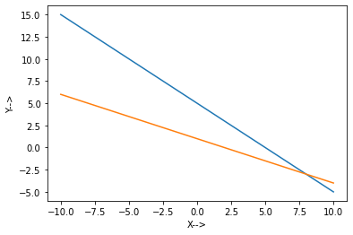

```
error= [[0.]
 [0.]]
```

```python
# Define Matrix A and B
A = np.matrix([[1,1], [2,4]])
b = np.matrix([[5], [4]])
print('A=',A,'\n')
print('b=',b,'\n')


# Determine the determinant of matrix A
Det = la.det(A)
print('Determinant=',Det,'\n')

# Determine the rank of the matrix A
rank = la.matrix_rank(A)
print('Matrix rank=',rank,'\n')

# Determine the Inverse of matrix A
A_inverse = la.inv(A)
print('A_inverse=',A_inverse,'\n')

# Determine the optimal solution
x_op = A_inverse @ b
print('x=',x_op,'\n')

# Plot the equations
plot2D(A, b)

# Validate the solution by obtaining the error
error = b - A @ x_op
print('error=',error,'\n')
```

For the following equation :

$$x+y+z=5$$$$2x+4y+z=4$$$$x+3y+4z=4$$

Write the code to :

1. Define Matrices $A$ and $B$
2. Determine the determinant of $A$
3. Determine the rank of $A$
4. Determine the Inverse of matrix $A$
5. Determine the optimal solution
6. Plot the equations
7. Validate the solution by obataining error

```python
# Function to plot 3D equations
def plot3D(A, b):
  # Plot the equations
  x = np.linspace(-10, 10)
  y = np.linspace(-10, 10)
  x, y = np.meshgrid(x, y)
  z = []

  A = np.array(A)
  b = np.array(b)
  for i in range(len(A)):
    z.append((b[i][0] - A[i][0]*x - A[i][1]*y) / A[i][2])

  fig, ax = plt.subplots(subplot_kw={"projection": "3d"})

  for i in range(len(A)):
    ax.plot_surface(x, y, z[i])

  plt.xlabel("X")
  plt.ylabel("Y")
  plt.show()
```

```
A= [[1 1 1]
 [2 4 1]
 [1 3 4]]

b= [[5]
 [4]
 [4]]

Determinant= 7.999999999999998

Matrix rank= 3

A_inverse= [[ 1.625 -0.125 -0.375]
 [-0.875  0.375  0.125]
 [ 0.25  -0.25   0.25 ]]

x= [[ 6.125]
 [-2.375]
 [ 1.25 ]]
```

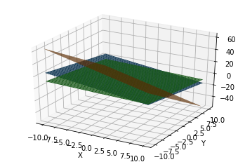

```
error= [[0.]
 [0.]
 [0.]]
```

```python
# Define Matrix A and B
A = np.matrix([[1,1,1], [2,4,1], [1,3,4]])
b = np.matrix([[5], [4], [4]])
print('A=',A,'\n')
print('b=',b,'\n')


# Determine the determinant of matrix A
Det = la.det(A)
print('Determinant=',Det,'\n')

# Determine the rank of the matrix A
rank = la.matrix_rank(A)
print('Matrix rank=',rank,'\n')

# Determine the Inverse of matrix A
A_inverse = la.inv(A)
print('A_inverse=',A_inverse,'\n')

# Determine the optimal solution
x_op = A_inverse @ b
print('x=',x_op,'\n')

# Plot the equations
plot3D(A, b)

# Validate the solution by obtaining the error
error = b - A @ x_op
print('error=',error,'\n')
```

# Case 2 :

Consider an eqauation $A$**x**=**b** where A is a Full rank but it is not a square matrix ($m>n$, dimension of $A$ is $m*n$) , Here if $b$ lies in the span of columns of $A$ then there is unique solution and it is given as *x$_{u}$*=$A^{-1}$*b* (here $A^{-1}$ is the pseudo inverse of matrix A), where *x$_{u}$* is the unique solution and the error is given as *b* - $A$*x$_{u}$*, If $b$ does not lie in the span of columns of $A$ then there are no solutions and the least square solution is given as *x$_{ls}$*=$A^{-1}$*b* (here $A^{-1}$ is the pseudo inverse of matrix A) and the error is given as *b* - $A$*x$_{ls}$*

Use the above information solve the following equations and compute the error :

$$x+z=0$$$$x+y+z=0$$$$y+z=0$$$$z=0$$

```
A= [[1 0 1]
 [1 1 1]
 [0 1 1]
 [0 0 1]]

b= [[0]
 [0]
 [0]
 [0]]

Matrix rank= 3

A_inverse= [[ 0.5   0.5  -0.5  -0.5 ]
 [-0.5   0.5   0.5  -0.5 ]
 [ 0.25 -0.25  0.25  0.75]]

x= [[0.]
 [0.]
 [0.]]
```

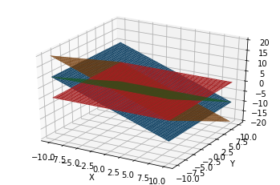

```
error= [[0.]
 [0.]
 [0.]
 [0.]]
```

```python
# Define matrix A and B
A = np.matrix([[1, 0, 1], [1, 1, 1], [0, 1, 1], [0, 0, 1]])
b = np.matrix([[0], [0], [0], [0]])
print('A=',A,'\n')
print('b=',b,'\n')

# Determine the rank of matrix A
rank = la.matrix_rank(A)
print('Matrix rank=',rank,'\n')

# Determine the pseudo-inverse of A (since A is not Square matrix)
A_inverse = la.pinv(A)
print('A_inverse=',A_inverse,'\n')

# Determine the optimal solution
x_op = A_inverse @ b
print('x=',x_op,'\n')

# Plot the equations
plot3D(A, b)

# Validate the solution by computing the error
error = b - A @ x_op
print('error=',error,'\n')
```

For the following equation :

$$x+y+z=35$$$$2x+4y+z=94$$$$x+3y+4z=4$$$$x+9y+4z=-230$$

Write the code to :

1. Define Matrices $A$ and $B$
2. Determine the rank of $A$
3. Determine the Pseudo Inverse of matrix $A$
4. Determine the optimal solution
5. Plot the equations
6. Validate the solution by obataining error

```
A= [[1 1 1]
 [2 4 1]
 [1 3 4]
 [1 9 4]]

b= [[  35]
 [  94]
 [   4]
 [-230]]

Matrix rank= 3

A_inverse= [[ 0.27001704  0.45570698  0.07666099 -0.25809199]
 [-0.06558773  0.02810903 -0.14480409  0.15417376]
 [ 0.04429302 -0.16183986  0.31856899 -0.03918228]]

x= [[111.9548552 ]
 [-35.69250426]
 [ -3.37649063]]
```

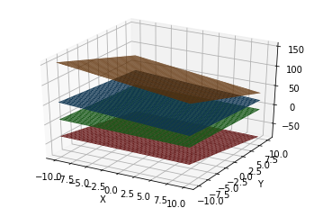

```
error= [[-37.88586031]
 [ 16.23679727]
 [ 12.6286201 ]
 [ -7.21635434]]
```

```python
# Define matrix A and B
A = np.matrix([[1, 1, 1], [2, 4, 1], [1, 3, 4], [1, 9, 4]])
b = np.matrix([[35], [94], [4], [-230]])
print('A=',A,'\n')
print('b=',b,'\n')

# Determine the rank of matrix A
rank = la.matrix_rank(A)
print('Matrix rank=',rank,'\n')

# Determine the pseudo-inverse of A (since A is not Square matrix)
A_inverse = la.pinv(A)
print('A_inverse=',A_inverse,'\n')

# Determine the optimal solution
x_op = A_inverse @ b
print('x=',x_op,'\n')

# Plot the equations
plot3D(A, b)

# Validate the solution by computing the error
error = b - A @ x_op
print('error=',error,'\n')
```

# Case 3 :

Consider an eqauation $A$**x**=**b** where A is not a Full rank matrix, Here if $b$ lies in the span of columns of $A$ then there are multiple solutions and one of the solution is given as *x$_{u}$*=$A^{-1}$*b* (here $A^{-1}$ is the pseudo inverse of matrix A), the error is given as *b* - $A$*x$_{u}$*, If $b$ does not lie in the span of columns of $A$ then there are no solutions and the least square solution is given as *x$_{ls}$*=$A^{-1}$*b* (here $A^{-1}$ is the pseudo inverse of matrix A) and the error is given as *b* - $A$*x$_{ls}$*

Use the above information solve the following equations and compute the error :

$$x+y+z=0$$$$3x+3y+3z=0$$$$x+2y+z=0$$

```
A= [[1 1 1]
 [3 3 3]
 [1 2 1]]

b= [[0]
 [0]
 [0]]

Matrix rank= 2

A_inverse= [[ 0.1  0.3 -0.5]
 [-0.1 -0.3  1. ]
 [ 0.1  0.3 -0.5]]

x= [[0.]
 [0.]
 [0.]]
```

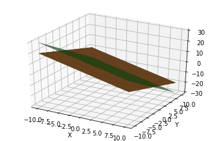

```
error= [[0.]
 [0.]
 [0.]]
```

```python
# Define matrix A and B
A = np.matrix([[1, 1, 1], [3, 3, 3], [1, 2, 1]])
b = np.matrix([[0], [0], [0]])
print('A=',A,'\n')
print('b=',b,'\n')

# Determine the rank of matrix A
rank = la.matrix_rank(A)
print('Matrix rank=',rank,'\n')

# Determine the pseudo-inverse of A (since A is not Square matrix)
A_inverse = la.pinv(A)
print('A_inverse=',A_inverse,'\n')

# Determine the optimal solution
x_op = A_inverse @ b
print('x=',x_op,'\n')

# Plot the equations
plot3D(A, b)

# Validate the solution by computing the error
error = b - A @ x_op
print('error=',error,'\n')
```

For the following equation :

$$x+y+z=0$$$$3x+3y+3z=2$$$$x+2y+z=0$$

Write the code to :

1. Define Matrices $A$ and $B$
2. Determine the rank of $A$
3. Determine the Pseudo Inverse of matrix $A$
4. Determine the optimal solution
5. Plot the equations
6. Validate the solution by obataining error

```
A= [[1 1 1]
 [3 3 3]
 [1 2 1]]

b= [[0]
 [2]
 [0]]

Matrix rank= 2

A_inverse= [[ 0.1  0.3 -0.5]
 [-0.1 -0.3  1. ]
 [ 0.1  0.3 -0.5]]

x= [[ 0.6]
 [-0.6]
 [ 0.6]]
```

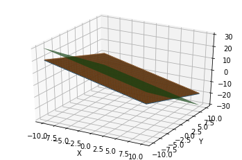

```
error= [[-6.0000000e-01]
 [ 2.0000000e-01]
 [-8.8817842e-16]]
```

```python
# Define matrix A and B
A = np.matrix([[1, 1, 1], [3, 3, 3], [1, 2, 1]])
b = np.matrix([[0], [2], [0]])

print('A=',A,'\n')
print('b=',b,'\n')

# Determine the rank of matrix A
rank = la.matrix_rank(A)
print('Matrix rank=',rank,'\n')

# Determine the pseudo-inverse of A (since A is not Square matrix)
A_inverse = la.pinv(A)
print('A_inverse=',A_inverse,'\n')

# Determine the optimal solution
x_op = A_inverse @ b
print('x=',x_op,'\n')

# Plot the equations
plot3D(A, b)

# Validate the solution by computing the error
error = b - A @ x_op
print('error=',error,'\n')
```

# Examples

Find the solution for the below equations and justify the case that they belong to

1.$2x+3y+5z=2,9x+3y+2z=5,5x+9y+z=7$

2.$2x+3y=1,5x+9y=4,x+y=0$

3.$2x+5y+10z=0,9x+2y+z=1,4x+10y+20z=5$

4.$2x+3y=0,5x+9y=2,x+y=-2$

5.$2x+5y+3z=0,9x+2y+z=0,4x+10y+6z=0$

```
Question 1:

A= [[2 3 5]
 [9 3 2]
 [5 9 1]]

b= [[2]
 [5]
 [7]]

Matrix rank= 3

A_inverse= [[-0.04950495  0.13861386 -0.02970297]
 [ 0.00330033 -0.07590759  0.13531353]
 [ 0.21782178 -0.00990099 -0.06930693]]

x= [[ 0.38613861]
 [ 0.57425743]
 [-0.0990099 ]]
```

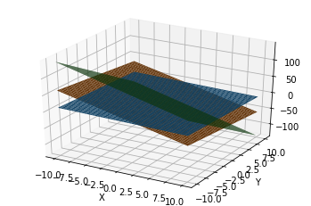

```
error= [[3.55271368e-15]
 [3.55271368e-15]
 [8.88178420e-16]]

Answer - Case 1
Justification - The matrix A is a full rank square matrix.




Question 2:

A= [[2 3]
 [5 9]
 [1 1]]

b= [[1]
 [4]
 [0]]

Matrix rank= 2

A_inverse= [[ 1.         -0.5         1.5       ]
 [-0.53846154  0.38461538 -0.84615385]]

x= [[-1.]
 [ 1.]]
```

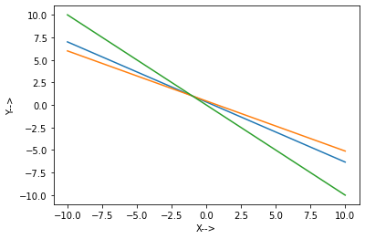

```
error= [[2.22044605e-15]
 [5.32907052e-15]
 [1.33226763e-15]]

Answer - Case 2
Justification - The matrix A is a full rank non-square matrix.




Question 3:

A= [[ 2  5 10]
 [ 9  2  1]
 [ 4 10 20]]

b= [[0]
 [1]
 [5]]

Matrix rank= 2

A_inverse= [[-0.00352332  0.11243523 -0.00704663]
 [ 0.00733679  0.00704663  0.01467358]
 [ 0.01703627 -0.02601036  0.03407254]]

x= [[0.07720207]
 [0.08041451]
 [0.14435233]]
```

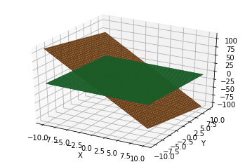

```
error= [[-2.00000000e+00]
 [-1.33226763e-15]
 [ 1.00000000e+00]]

Answer - Case 3
Justification - The matrix A is not a full rank matrix.




Question 4:

A= [[2 3]
 [5 9]
 [1 1]]

b= [[ 0]
 [ 2]
 [-2]]

Matrix rank= 2

A_inverse= [[ 1.         -0.5         1.5       ]
 [-0.53846154  0.38461538 -0.84615385]]

x= [[-4.        ]
 [ 2.46153846]]
```

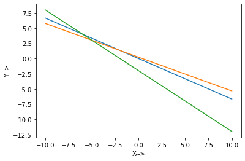

```
error= [[ 0.61538462]
 [-0.15384615]
 [-0.46153846]]

Answer - Case 2
Justification - The matrix A is a full rank non-square matrix.




Question 5:

A= [[ 2  5  3]
 [ 9  2  1]
 [ 4 10  6]]

b= [[0]
 [0]
 [0]]

Matrix rank= 2

A_inverse= [[-0.00927612  0.12136974 -0.01855223]
 [ 0.0319029  -0.03424361  0.06380581]
 [ 0.01967924 -0.02384049  0.03935847]]

x= [[0.]
 [0.]
 [0.]]
```

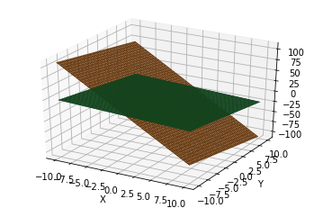

```
error= [[0.]
 [0.]
 [0.]]

Answer - Case 3
Justification - The matrix A is not a full rank matrix.
```

```python
# Matrices A & b
As = []
bs = []
# 1
As.append(np.matrix([[2, 3, 5], [9, 3, 2], [5, 9, 1]]))
bs.append(np.matrix([[2], [5], [7]]))
# 2
As.append(np.matrix([[2, 3], [5, 9], [1, 1]]))
bs.append(np.matrix([[1], [4], [0]]))
# 3
As.append(np.matrix([[2, 5, 10], [9, 2, 1], [4, 10, 20]]))
bs.append(np.matrix([[0], [1], [5]]))
# 4
As.append(np.matrix([[2, 3], [5, 9], [1, 1]]))
bs.append(np.matrix([[0], [2], [-2]]))
# 5
As.append(np.matrix([[2, 5, 3], [9, 2, 1], [4, 10, 6]]))
bs.append(np.matrix([[0], [0], [0]]))

# Function to find solution and case for given equations
def findSol(A, b):
  print('A=',A,'\n')
  print('b=',b,'\n')

  # Determine the rank of matrix A
  rank = la.matrix_rank(A)
  print('Matrix rank=',rank,'\n')

  # Determine the pseudo-inverse of A (since A is not Square matrix)
  A_inverse = la.pinv(A)
  print('A_inverse=',A_inverse,'\n')

  # Determine the optimal solution
  x_op = A_inverse @ b
  print('x=',x_op,'\n')

  # Plot the equations
  dim = len(np.array(A)[0])
  if dim == 3:
    plot3D(A, b)
  elif dim == 2:
    plot2D(A, b)

  # Validate the solution by computing the error
  error = b - A @ x_op
  print('error=',error,'\n')

  # Check if it is square matrix and/or full matrix
  rows = len(np.array(A))
  cols = len(np.array(A)[0])
  isSquare = (rows == cols)
  if rows > cols:
    isFullRank = (rank == cols)
  else:
    isFullRank = (rank == rows)

  # Choose the case
  if isFullRank and isSquare:
    # Must be case 1
    print("Answer - Case 1 \nJustification - The matrix A is a full rank square matrix.")
  elif isFullRank and not isSquare:
    # Must be case 2
    print("Answer - Case 2 \nJustification - The matrix A is a full rank non-square matrix.")
  elif not isFullRank:
    # Must be case 3
    print("Answer - Case 3 \nJustification - The matrix A is not a full rank matrix.")

for i, (A, b) in enumerate(zip(As, bs)):
  print(f"Question {i+1}:\n")
  findSol(A, b)
  print("\n\n\n")
```